# Biostat 203B Homework 2

## Q3

`ICUSTAYS.csv` (https://mimic.physionet.org/mimictables/icustays/) contains data about Intensive Care Units (ICU) stays. Summarize following variables using appropriate graphs:

- length of ICU stay
- first ICU unit
- gender
- age

**Solution** First, parse the ‘ICUSTAYS.csv’ data.

```r
ICU <- read_csv("/home/203bdata/mimic-iii/ICUSTAYS.csv")
```

### Length of ICU Stay

Similar as Q2, age at admission, I will treat patient who had been transfered into ICU for multiple times as different observations. One patient could contribute to multiple lengths of ICU stay. Same applies to the following plots for ‘First ICU Unit’ and ‘Age’.

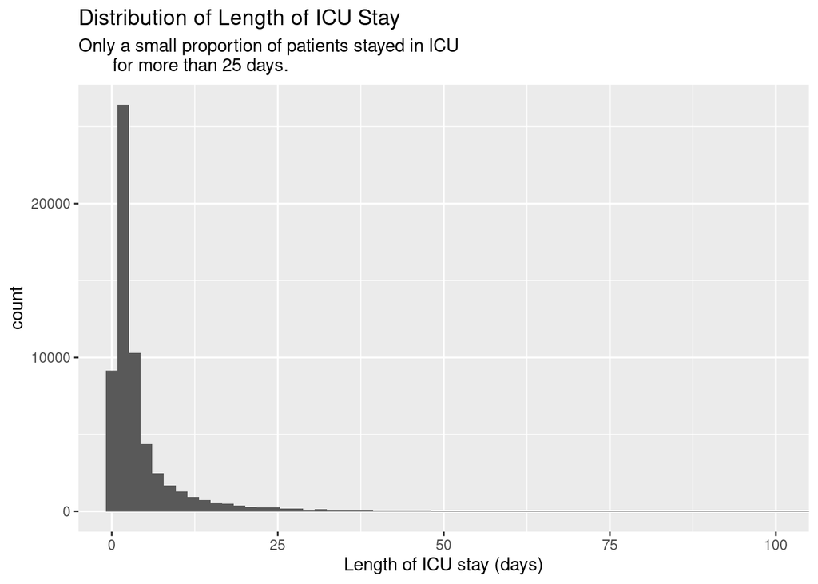

```r
ICU %>%
  ggplot(aes(x = LOS)) +
  coord_cartesian(xlim = c(0, 100)) +
  geom_histogram(bins = 100) +
  labs(x = "Length of ICU stay (days)",
       title = "Distribution of Length of ICU Stay",
       subtitle = "Only a small proportion of patients stayed in ICU
       for more than 25 days.")
```

### First ICU Unit

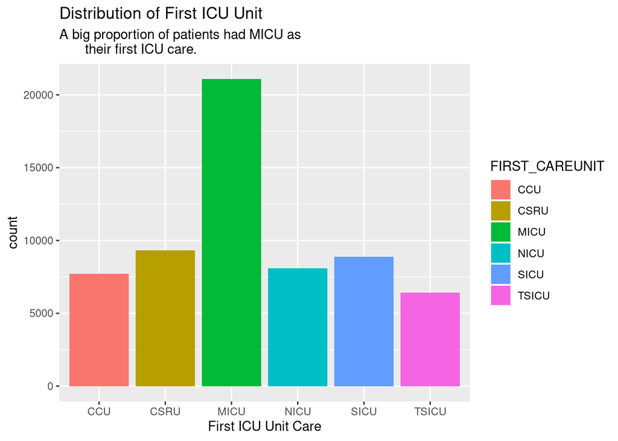

```r
ICU %>%
  ggplot() +
  geom_bar(mapping = aes(x = FIRST_CAREUNIT, fill = FIRST_CAREUNIT)) +
  labs(x = "First ICU Unit Care",
       title = "Distribution of First ICU Unit",
       subtitle = "A big proportion of patients had MICU as
       their first ICU care.")
```

To summerize the other two variables, I’d like to link the ‘ICUSTAYS.csv’ to the ‘PATIENTS.csv’:

```r
iP <- left_join(ICU, patient, by = "SUBJECT_ID")
```

### Gender

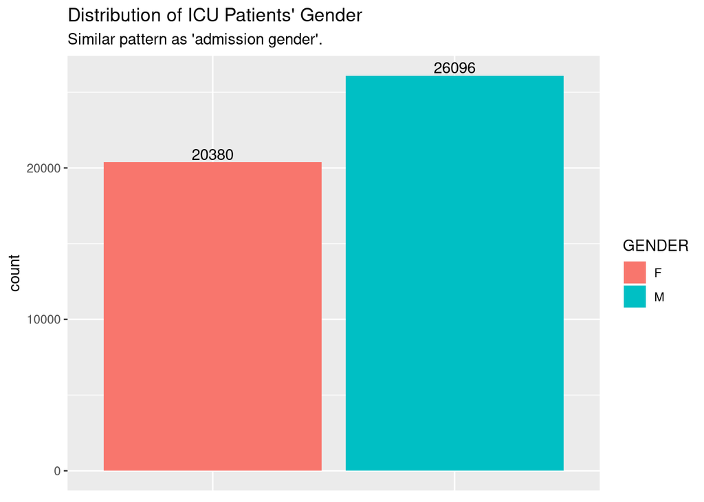

```r
iP %>%
  distinct(SUBJECT_ID, .keep_all = TRUE) %>%
  ggplot(mapping = aes(x = GENDER,
                       fill = GENDER)) +
  geom_bar() +
  theme(axis.text.x=element_blank(),
        axis.ticks.x=element_blank(),
        axis.title.x=element_blank()) +
  geom_text(stat = 'count', aes(label = ..count.., vjust = -0.2)) +
  labs(title = "Distribution of ICU Patients' Gender",
       subtitle = "Similar pattern as 'admission gender'.")
```

### Age

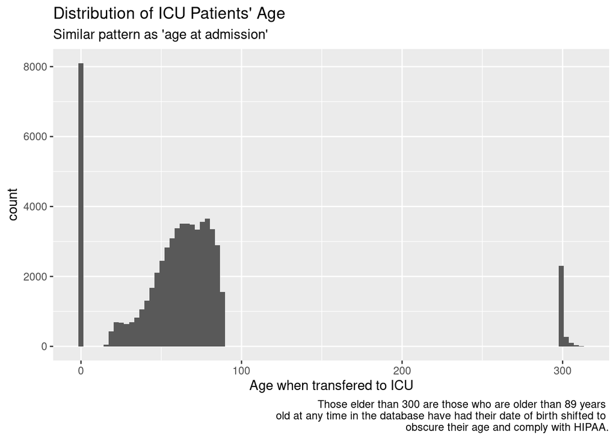

```r
iP %>%
  mutate(age_ICU = as.numeric(as.duration(INTIME - DOB) / 31536000)) %>%
  ggplot(aes(x = age_ICU)) +
  geom_histogram(bins = 100) +
  labs(x = "Age when transfered to ICU",
       title = "Distribution of ICU Patients' Age",
       subtitle = "Similar pattern as 'age at admission'",
       caption = "Those elder than 300 are those who are older than 89 years
       old at any time in the database have had their date of birth shifted to
       obscure their age and comply with HIPAA.")
```

## Q4

### Potential Values of ITEMID that Correspond to ‘Systolic’

`CHARTEVENTS.csv` (https://mimic.physionet.org/mimictables/chartevents/) contains all the charted data available for a patient. During their ICU stay, the primary repository of a patient’s information is their electronic chart. The `ITEMID` variable indicates a single measurement type in the database. The `VALUE` variable is the value measured for `ITEMID`.

`D_ITEMS.csv` (https://mimic.physionet.org/mimictables/d_items/) is the dictionary for the `ITEMID` in `CHARTEVENTS.csv`. Find potential values of `ITEMID` that correspond to systolic blood pressure, i.e., `LABEL` contains the string `systolic`.

**Solution**

First parse the data:

```r
chartevent <- read_csv("/home/203bdata/mimic-iii/CHARTEVENTS.csv")
ditem <- read_csv("/home/203bdata/mimic-iii/D_ITEMS.csv")
```

Find the potential “ITEMID” that contains systolic blood pressure:

```r
sys_ID <- subset(ditem$ITEMID, str_detect(ditem$LABEL, "systolic"))
sys_ID
```

```
## [1] 226850 226852 220050 220059 220179
```

### Tibble

Compile a tibble that contains the first ICU stay of unique patients, with the patient’s demographic information, the first systolic blood pressure measurement during ICU stay, and whether the patient died within 30 days of hospitcal admission.

**Solution**

```r
temp <- chartevent %>%
          filter(ITEMID %in% sys_ID) %>%
          group_by(SUBJECT_ID) %>%
          arrange(CHARTTIME) %>%
          distinct(SUBJECT_ID, .keep_all = TRUE) %>%
          select(SUBJECT_ID, VALUE)
temp
```

```
## # A tibble: 438 x 2
## # Groups:   SUBJECT_ID [438]
##    SUBJECT_ID VALUE
##         <dbl> <dbl>
##  1        357   112
##  2       8231    76
##  3      10428   106
##  4       1578   126
##  5       9144   104
##  6       4962    82
##  7       8427   100
##  8        188   133
##  9       9965   113
## 10       5382   110
## # … with 428 more rows
```

Second, since each patient can be transfered into ICU for multiple times, I only select their first time by looking for the earliest time that each patient was transfered into ICU. They are stored in the variable INTIME (first ICU stay). Then, I link the corresponding demography information and the value of first systolic blood pressure measurement (VALUE) to each patient. In addition, I add a variable (DIED_30) that determines if the patient died within 30 days of hospitcal admission by using (DEATHTIME - ADMITTIME). If TRUE, then this patient died within 30 days of hospital admission; if FALSE, this patient did not die within 30 days but did die after 30 days in the hospital; if NA, this patient was still alive at the time he or she was discharged from the hospital.

```r
ICU %>%
  group_by(SUBJECT_ID) %>%
  arrange(INTIME) %>%
  distinct(SUBJECT_ID, .keep_all = TRUE) %>%
  left_join(patient, by = "SUBJECT_ID") %>%
  left_join(temp, by = "SUBJECT_ID") %>%
  left_join(admission, by = "HADM_ID") %>%
  mutate(DIED_30 = ((DEATHTIME - ADMITTIME) < 30)) %>%
  select(SUBJECT_ID.x, INTIME, GENDER, DOB, LANGUAGE,
         MARITAL_STATUS, VALUE, DIED_30) %>%
  print(width = Inf)
```

```
## # A tibble: 46,476 x 8
## # Groups:   SUBJECT_ID.x [46,476]
##    SUBJECT_ID.x INTIME              GENDER DOB                 LANGUAGE
##           <dbl> <dttm>              <chr>  <dttm>              <chr>
##  1        82574 2100-06-07 20:00:22 M      2044-04-23 00:00:00 ENGL
##  2        29156 2100-06-09 01:39:43 M      2028-04-23 00:00:00 CANT
##  3        12001 2100-06-14 04:56:39 F      2028-10-27 00:00:00 <NA>
##  4        21081 2100-06-14 14:33:55 F      2067-04-01 00:00:00 <NA>
##  5        32096 2100-06-22 06:34:52 F      2070-12-13 00:00:00 ENGL
##  6        20957 2100-06-26 18:43:00 F      2052-04-04 00:00:00 <NA>
##  7         9319 2100-07-02 01:12:19 F      2018-04-05 00:00:00 ENGL
##  8        31585 2100-07-02 22:27:28 M      1800-07-02 00:00:00 ENGL
##  9        28711 2100-07-02 22:28:32 M      2100-07-02 00:00:00 <NA>
## 10         1291 2100-07-04 10:29:48 F      2100-07-04 00:00:00 <NA>
##    MARITAL_STATUS VALUE DIED_30
##    <chr>          <dbl> <lgl>
##  1 SINGLE            NA NA
##  2 MARRIED           NA TRUE
##  3 MARRIED           NA NA
##  4 SINGLE            NA NA
##  5 MARRIED           NA NA
##  6 MARRIED           NA NA
##  7 WIDOWED           NA NA
##  8 WIDOWED           NA NA
##  9 <NA>              NA NA
## 10 <NA>              NA NA
## # … with 46,466 more rows
```